# Pre-processing ASVs with Phyloseq

Antone Jung

2025-03-30

# Goals

First, we will use the [phyloseq package](https://joey711.github.io/phyloseq/) to combine all of our data objects that we exported from the DADA2 workflow (`asv_table`, `tax_table`, and metadata) and incorporate them into a single [specialized S4 R Data object](https://adv-r.hadley.nz/s4.html), known as a phyloseq object. Then, we will remove any potential contaminants and evaluate the accuracy of our sequencing run. Finally, we will write our our single `raw_preprocessed_physeq` phyloseq data object.

## Specific Steps:

1. Load in data that we’ve generated in `analysis/02_AssignASVs.Rmd` and fix all of the names to match each other. *The names must match for us to incorporate them into the S4 phyloseq object*:
   1. `asv_table`: ASVs (rows) x Samples (columns)
   2. `tax_table`: ASV (rows) x Taxonomy (columns)
   3. `metadata`: Samples (rows) x All our data (*e.g. pH, Temp, treatment group, etc*; columns)
2. Combine the data into a phyloseq object.
3. Remove any contaminating ASVs that are **chloroplasts**.
4. Remove ASVs that are **mitochondria**.
5. Evaluate any ASVs from the **negative controls**. Then, remove negative controls.
6. Evaluate the mock community or **positive control** to learn the accuracy of sequencing.
7. Check for **reverse complements**.
8. Check the **sequencing depth** of samples. Remove samples that obviously have too few reads.
9. Write a `raw_preprocessed_physeq` to be used in the next step of our workflow.

## Input

1. **Metadata**: `metadata.csv` and `data/01_DADA2/track_read_counts.RData`.
2. **ASV table**: `data/01_DADA2/ASV_table.csv`
3. **Taxonomy Table**: `data/01_DADA2/ASV_taxonomy.tsv`

## Output

1. A **pre-processed S4 phyloseq object**: `raw_preprocessed_physeq.RData`.

#### Why use phyloseq?

It’s about making our job as microbial ecologists easier! Phyloseq helps us as researchers to:

- Efficiently integrates multiple data types in (microbiome/sequencing) research.
- Supports biodiversity analyses (alpha, beta diversity) and statistical tests, which we are working towards.
- Access built-in functions for filtering (`prune_taxa()`, `prune_samples()`), subsetting (`subset_taxa()`, `subset_samples()`), and normalizing data across a database.
- Enables easy visualization with functions like `plot_richness()`, `ordinate()`, and `plot_ordination()`.

# Set Environment

## Load Packages

```r
#install.packages("BiocManager")
#BiocManager::install("Biostrings")

# NOTE, you will need to install the following 2 packages to
# re-create the negative control plots below!
install.packages("ggpubr")
install.packages("rstatix")
# Load packages with pacman
# Be sure that you load dada2 & Patchwork, which we didn't do in class on March 12th
pacman::p_load(devtools, phyloseq, dada2, patchwork, Biostrings, tidyverse,
               # Note to add ggpubr & rstatix!!
               ggpubr, rstatix, install = FALSE)
```

## 1. Load Data

### 1a. Metadata

Here, we will load in our **metadata** files, which include:

1. `data/metadata.csv`: This file contains all of our samples and also any measured variables, including station, date of collection, depth of sample, temperature, pH, salinity, etc.
2. `data/01_DADA2/track_read_counts.RData`: This file contains how many reads we maintained in our samples through the DADA2 workflow.

**Where’s your metadata?**

If you **downloaded a dataset from the NCBI/ENA**, then you’ve likely have data that matches with your fastq files that you’ve downloaded via the SRA “Run Selector”. You will need to have the data that matches your scientific question–remember, we are doing science!? (*It’s so easy to get lost in all the nitty gritty of our bioinformatics project.*)

If you have **data from your own research or from you lab’s research**, hopefully you have access to a curated, quality controlled, and cleaned up table where you can match the current name of your samples to their sample information (*e.g.,* disease state, host type, experimental group, environmental parameters, etc). This table will include the column(s) that will match with your scientific question.

```r
# load in metadata
metadata_df <-
  read_tsv("data/metadata.txt") %>%
  dplyr::select(.,run_accession, scientific_name, experiment_title) %>%
  filter(., grepl("Experiment 1",experiment_title)) %>%
  rename(c("sample_names" = "run_accession")) %>%
  mutate(soil_type = ifelse(grepl("Lansing", experiment_title),"Lansing","")) %>%
  mutate(soil_type = ifelse(grepl("Pendelton", experiment_title),"Pendelton",soil_type)) %>%
  mutate(soil_type = ifelse(grepl("Sand", experiment_title),"Sand",soil_type)) %>%
  mutate(soil_type = ifelse(grepl("Florence", experiment_title), "Florence", soil_type)) %>%
  mutate(soil_type = ifelse(grepl("fungus", scientific_name),"Neg",soil_type)) %>%
  mutate(soil_type = ifelse(grepl("synthetic", scientific_name),"Pos",soil_type)) %>% mutate(Sample_or_Control = ifelse(grepl("Neg", soil_type), FALSE, TRUE)) %>%
  mutate(Sample_or_Control = ifelse(grepl("Pos", soil_type), FALSE, Sample_or_Control))
# Inspect
head(metadata_df)
```

```
## # A tibble: 6 × 5
##   sample_names scientific_name      experiment_title soil_type Sample_or_Control
##   <chr>        <chr>                <chr>            <chr>     <lgl>
## 1 SRR12183158  rhizosphere metagen… Illumina MiSeq … Sand      TRUE
## 2 SRR12183139  soil metagenome      Illumina MiSeq … Sand      TRUE
## 3 SRR12183147  rhizosphere metagen… Illumina MiSeq … Sand      TRUE
## 4 SRR12183238  fungus metagenome    Illumina MiSeq … Neg       FALSE
## 5 SRR12183239  soil metagenome      Illumina MiSeq … Florence  TRUE
## 6 SRR12183242  fungus metagenome    Illumina MiSeq … Neg       FALSE
```

```r
dim(metadata_df)
```

```
## [1] 51  5
```

```r
# include dada2 output
load("data/01_DADA2/track_read_counts.RData")

# Take a look
glimpse(track_counts_df)
```

```
## Rows: 51
## Columns: 6
## $ sample_names <chr> "SRR12183139_1.fastq.gz", "SRR12183147_1.fastq.gz", "SRR1…
## $ denoisedF    <dbl> 34565, 28298, 33520, 28515, 21088, 20608, 21745, 42950, 3…
## $ denoisedR    <dbl> 34534, 28313, 33560, 28548, 21168, 20591, 21812, 43097, 3…
## $ merged       <dbl> 34131, 27814, 32974, 26091, 19702, 18187, 19362, 34600, 3…
## $ nochim       <dbl> 32332, 25728, 30590, 25822, 19242, 18027, 18705, 34122, 2…
## $ num_ASVs     <dbl> 240, 170, 204, 767, 624, 784, 843, 1443, 2, 1198, 16, 10,…
```

```r
dim(track_counts_df)
```

```
## [1] 51  6
```

```r
# Check filenames
head(track_counts_df$sample_names)
```

```
## [1] "SRR12183139_1.fastq.gz" "SRR12183147_1.fastq.gz" "SRR12183158_1.fastq.gz"
## [4] "SRR12183176_1.fastq.gz" "SRR12183187_1.fastq.gz" "SRR12183204_1.fastq.gz"
```

```r
# Fix sample names in track_reads
track_counts_df$sample_names <- sapply(strsplit(track_counts_df$sample_names, "_"), `[`, 1)

# Intuition check
head(track_counts_df$sample_names)
```

```
## [1] "SRR12183139" "SRR12183147" "SRR12183158" "SRR12183176" "SRR12183187"
## [6] "SRR12183204"
```

```r
# What's different?
setdiff(track_counts_df$sample_names, metadata_df$sample_names)
```

```
## character(0)
```

```r
# Let's do a filtering join with left_join
metadata_final_df <-
  metadata_df %>%
  left_join(., track_counts_df, by = "sample_names") %>%
  # sample names to the rownames to merge into phyloseq
  column_to_rownames(var = "sample_names")

# Check
dim(metadata_final_df)
```

```
## [1] 51  9
```

### 1b. ASV Table

Now, let’s load in the ASV count table that we created within DADA2 in `analysis/02_AssignASVs.Rmd`.

```r
asv_df <-
  read.delim(file = "data/01_DADA2/ASV_table.tsv", sep = "\t",
           # add the column names and row names
           header = TRUE, row.names = 1)

# Inspect
asv_df[1:3, 1:3]
```

```
##          SRR12183139 SRR12183147 SRR12183158
## ASV_0001           0           0           0
## ASV_0002           0           0           0
## ASV_0003           0           0           0
```

```r
# Final inspection
head(colnames(asv_df))
```

```
## [1] "SRR12183139" "SRR12183147" "SRR12183158" "SRR12183176" "SRR12183187"
## [6] "SRR12183204"
```

```r
asv_df[1:3, 1:3]
```

```
##          SRR12183139 SRR12183147 SRR12183158
## ASV_0001           0           0           0
## ASV_0002           0           0           0
## ASV_0003           0           0           0
```

### 1c. Taxonomy Table

And, let’s also load the taxonomy table that we created in `analysis/02_AssignASVs.Rmd`.

```r
tax_df <-
  read.delim("data/01_DADA2/ASV_taxonomy.tsv", sep = "\t",
           header = TRUE, row.names = 1)

# Inspect
dim(tax_df)
```

```
## [1] 9614    9
```

```r
dim(asv_df)
```

```
## [1] 9614   51
```

```r
# Add check
stopifnot(rownames(asv_df) == rownames(tax_df))
```

# 2. Handoff to phyloseq

This is where we will combine our metadata, asv count table, and taxonomy table into a single data S4 data object in R, which we will call `raw_physeq` for now.

```r
raw_physeq <-
  phyloseq(otu_table(asv_df, taxa_are_rows = TRUE),
         sample_data(metadata_final_df),
         tax_table(as.matrix(tax_df)))

# Check out
raw_physeq
```

```
## phyloseq-class experiment-level object
## otu_table()   OTU Table:         [ 9614 taxa and 51 samples ]
## sample_data() Sample Data:       [ 51 samples by 9 sample variables ]
## tax_table()   Taxonomy Table:    [ 9614 taxa by 9 taxonomic ranks ]
```

```r
# save
save(raw_physeq, file = "data/03_PreProcessing/raw_physeq.RData")
```

# Clean up the data!

**Chloroplasts** and **mitochondria** need to be removed from 16S datasets because they contain their own 16S rRNA genes, which are evolutionarily derived from bacteria. These organelles can be unintentionally amplified during PCR, especially in samples from plants (chloroplasts) or animals (mitochondria), leading to misleading results by inflating microbial diversity.

## 3. Remove chloroplasts

```r
noChloros_physeq <-
  raw_physeq %>%
  subset_taxa(Order != "Chloroplast" | is.na(Order))

# How many ASVs were chloroplasts?
numChloros_ASVs <- ntaxa(raw_physeq) - ntaxa(noChloros_physeq)
```

There were 22 ASVs that were chloroplasts.

## 4. Remove Mitochondria

```r
noChlorosMitos_physeq <-
  noChloros_physeq %>%
  subset_taxa(Family != "Mitochondria" | is.na(Family))

# How many ASVs were mitochondria?
numMitos_ASVs <- ntaxa(noChloros_physeq) - ntaxa(noChlorosMitos_physeq)
```

There were 155 ASVs that were mitochondria in the data set.

INTERPRETATION #1: There were 22 Chloroplasts and 155 Mitochondria in my sample, which is a lot, but compared to the 9614 total taxa, is a minor part of my data.

# Evaluate and remove the control samples

Now, let’s take a look at the negative controls and then make a decision about whether or not to remove the ASVs that we found in our controls

1. Negative controls
2. ASVs found within the negative controls and their distribution in the samples.
3. Evaluate the mock community

## 5. Negative Controls

Including negative controls in your 16S sequencing workflow is a critical step that helps you identify potential contamination and confidently interpret your results—**especially if you’re working with low-biomass** samples like water, air, or host-associated (*e.g.,* skin, etc) surfaces.

Even in the cleanest labs, contamination can creep in at any point in the pipeline: from the DNA extraction kit, PCR reagents, plastic consumables, or even aerosols in the lab. These contaminants often include low-level bacterial DNA that can be amplified just as efficiently as your true sample DNA, leading to false signals in your data. Negative controls help you detect and remove these artifacts.

The main types of negative controls you should consider including in your 16S rRNA gene analyses include the following:

1. **DNA Extraction Blank (Extraction Negative Control):** This control is processed alongside your samples but without any actual biological material—you just use the extraction buffer or nuclease-free water. It goes through the entire DNA extraction process, just like your real samples. Each time you open a new kit another DNA extraction blank should be created! In our lab, we always record the lot number of our extraction kit and add it to the DNA metadata for that sample.
   - *Why it’s important:* This control helps you detect contamination introduced during the extraction step—often from kits (a phenomenon known as the kitome), tubes, pipette tips, or other surfaces.
2. **PCR No-Template Control (NTC):** For this control, you set up a PCR reaction using water instead of DNA as the template. Everything else—primers, polymerase, buffer—is the same as your actual PCR reactions.
   - *Why it’s important:* This checks for contaminants introduced during PCR setup, such as aerosolized DNA, primer dimer artifacts, or contamination from reagents like Taq or water.
   - *Note:* A NTC control should be included in your dataset from each step of PCR that your sample goes through. For example, **in the standard Illumina 2-step PCR library prep, two separate NTC controls should be included** for both the 1st PCR step where the 16S rRNA gene-specific primers are used with the Illumina adapter overhangs, and the 2nd PCR step where the indices and P5 and P7 are added to the end of the amplicons. Therefore, a blank sample that is carried all the way through barcoding, library prep, pooling, and sequencing. Treat it exactly like a real sample in your workflow. These control helps detect contamination introduced within and after PCR, such as cross-contamination during amplicon pooling, barcode cross-talk, or reagent contamination during library preparation.
3. **Field Control:** This type of control is a blank sample (*e.g.,* sterile water, buffer, or a clean swab) that is handled *exactly* like your real samples, but without exposure to the environment or biological material that is being studied. It goes through:
   - The same collection materials (e.g., bottles, filters, swabs).
   - The same handling (e.g., gloves, tools, transport containers).
   - And is stored or processed at the same time and under the same conditions as your actual field samples.
   - Extracted and prepared exactly as every other sample.
   - *What are examples of field controls?*
     - Examples:
       - *Water samples:* Pour sterile water into a sterile sampling bottle at the site (without exposing it to the lake/river), filter it as if it were a sample.
       - *Swab samples:* Open a sterile swab, wave it near the sampling area without touching anything, then store it with your other samples.
       - *Sediment or soil samples*: Open up the collection tube to the open air and use a clean scoop (with the same cleaning method as you would between actual samples) to transfer sterile material or nothing at all into your collection container.

Negative controls are not optional—they are essential for data quality, reproducibility, and trust in your results. By including extraction blanks, PCR no-template controls, and field controls, you’ll be equipped to identify contamination, assess its impact, and clean your data before making biological interpretations.

**So, here in this section we will use the negative control samples to:**

1. Make a phyloseq object that only has our negative controls.
2. Evaluate negative control ASVs in samples versus controls by visualizing potential ASV contaminants in negative controls using plots. Here, we will manually do it, but please be aware that there’s also the [decontam R Package](https://benjjneb.github.io/decontam/vignettes/decontam_intro.html) that does this, too!
3. Remove any ASVs in the negative controls.

### 5a. Create negative control phyloseq object

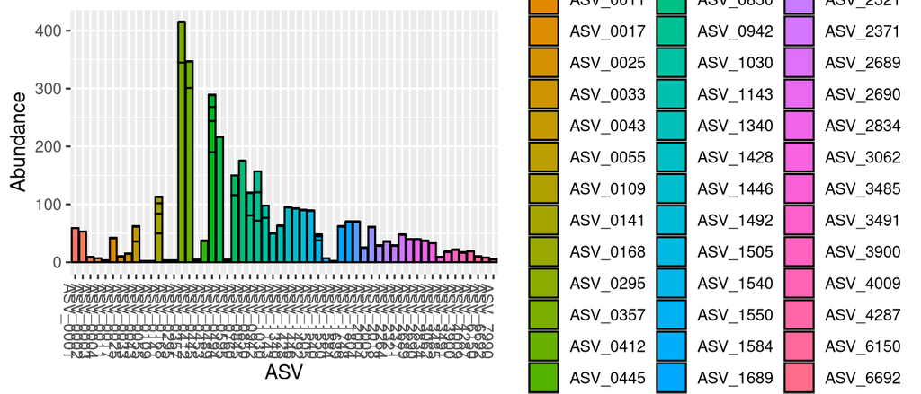

```r
# Create a phyloseq object with only negative controls
neg_control_physeq <-
  noChlorosMitos_physeq %>%
  subset_samples(., soil_type == "Neg") %>%
  # rm ASVs with 0 counts
  prune_taxa(taxa_sums(.) > 0, .)

# Take a look at the ASV abundances in our negative controls
neg_control_physeq %>%
  plot_bar(., "ASV", fill = "ASV")
```

### 5b. Evaluate Negative Control ASVs in Samples vs Controls

```r
# What's the abundance of these neg control ASVs in real samples?
# create vector of ASVs
neg_controlASVs_vec <-
  neg_control_physeq %>%
  tax_table() %>%
  data.frame() %>%
  dplyr::select(ASV) %>%
  as.vector()

# use vector to subset from larger dataset, creating a new phyloseq object
neg_controlASV_physeq <-
  noChlorosMitos_physeq %>%
  subset_taxa(., ASV %in% neg_controlASVs_vec$ASV) %>%
  # we will also need to remove the positive controls from the samples!
  # We will evaluate the Mock community a bit later on. :)
  subset_samples(., soil_type != "Pos")

# Take look
neg_controlASV_physeq
```

```
## phyloseq-class experiment-level object
## otu_table()   OTU Table:         [ 56 taxa and 45 samples ]
## sample_data() Sample Data:       [ 45 samples by 9 sample variables ]
## tax_table()   Taxonomy Table:    [ 56 taxa by 9 taxonomic ranks ]
```

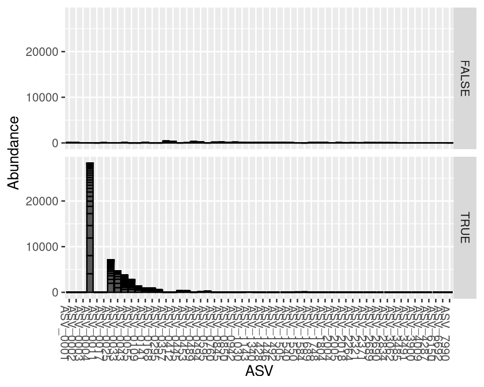

```r
# Plot Abundances of neg control ASVs in samples versus controls
neg_controlASV_physeq %>%
  plot_bar(., "ASV", facet_grid = Sample_or_Control~.)
```

Now, let’s take a look a bit more of a closer look at each ASV and evaluate the statistical significance.

```r
# Calculate the phylum relative abundance
# Note: The read depth MUST be normalized in some way: scale_reads
asv_negControls_df <-
  neg_controlASV_physeq %>%
  # agglomerate at the ASV level
  tax_glom(taxrank = "ASV") %>%
  # Melt to a long format
  psmelt()

# Check
head(asv_negControls_df)
```

```
##          OTU      Sample Abundance        scientific_name
## 169 ASV_0004 SRR12183366      4075        soil metagenome
## 148 ASV_0004 SRR12183321      3977        soil metagenome
## 171 ASV_0004 SRR12183176      3850        soil metagenome
## 147 ASV_0004 SRR12183309      2714        soil metagenome
## 160 ASV_0004 SRR12183377      2635        soil metagenome
## 285 ASV_0025 SRR12183554      1990 rhizosphere metagenome
##                                                                                                                                                                          experiment_title
## 169      Illumina MiSeq sequencing: 16S amplicon of CH sample from mesocosm with Sand soil and Gv Experiment 1. Samples collected 81 days after soil in-growth cores inserted in mesocosm
## 148  Illumina MiSeq sequencing: 16S amplicon of CH sample from mesocosm with Florence soil and Gv Experiment 1. Samples collected 81 days after soil in-growth cores inserted in mesocosm
## 171  Illumina MiSeq sequencing: 16S amplicon of CH sample from mesocosm with Florence soil and Gv Experiment 1. Samples collected 81 days after soil in-growth cores inserted in mesocosm
## 147 Illumina MiSeq sequencing: 16S amplicon of CH sample from mesocosm with Pendelton soil and Gv Experiment 1. Samples collected 81 days after soil in-growth cores inserted in mesocosm
## 160      Illumina MiSeq sequencing: 16S amplicon of CH sample from mesocosm with Sand soil and Gv Experiment 1. Samples collected 81 days after soil in-growth cores inserted in mesocosm
## 285   Illumina MiSeq sequencing: 16S amplicon of RT sample from mesocosm with Lansing soil and Gv Experiment 1. Samples collected 81 days after soil in-growth cores inserted in mesocosm
##     soil_type Sample_or_Control denoisedF denoisedR merged nochim num_ASVs
```

[output cut: 20 more lines]

```r
dim(asv_negControls_df)
```

```
## [1] 2520   20
```

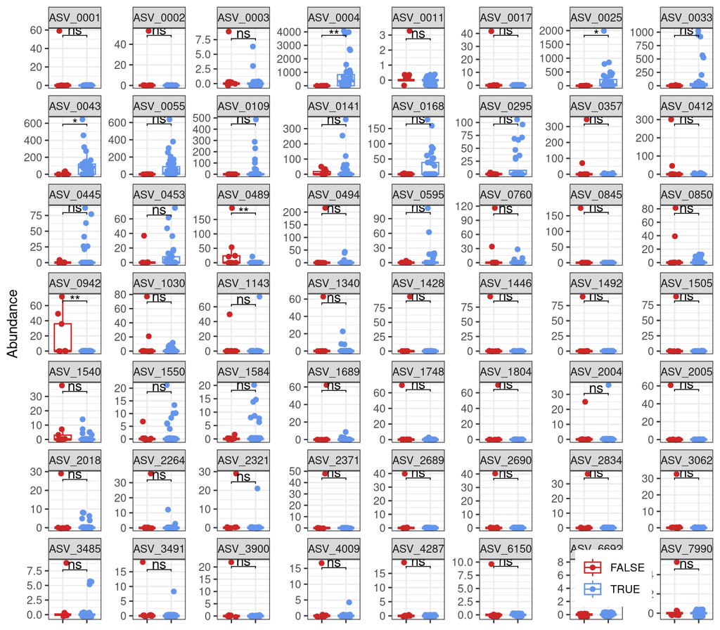

```r
# Statistically test!
negControl_ASV_statTest <-
  asv_negControls_df %>%
  group_by(ASV) %>%
  wilcox_test(Abundance ~ Sample_or_Control) %>%
  # Add the x and y positions for plotting
  adjust_pvalue(method = "fdr") %>%
  # Make the significance values be stars for plotting
  add_significance() %>%
  # Calculate where to place it on the facet grid plot
  add_xy_position(x = "Sample_or_Control", fun = "max", scales = "free") %>%
  # bring the pvalues a lil lower
  mutate(y.position = y.position * 0.82)

## Using ggpubr
ggboxplot(
  asv_negControls_df,
  x = "Sample_or_Control", y = "Abundance",
  color = "Sample_or_Control",
  facet.by = "ASV", scales = "free_y",add = "jitter") +
  stat_pvalue_manual(negControl_ASV_statTest) +
  scale_color_manual(values = c("firebrick3", "cornflowerblue")) +
  scale_fill_manual(values = c("firebrick3", "cornflowerblue")) +
  theme_bw() +
  theme(axis.text.x = element_blank(), axis.title.x = element_blank(),
        legend.title = element_blank(), legend.position = c(0.85, 0.07))
```

#### Check Taxonomy

```r
asv_negControls_df %>%
  dplyr::filter(OTU %in% neg_controlASVs_vec$ASV) %>%
  dplyr::select(Kingdom:ASV) %>%
  unique() %>%
  arrange(ASV)
```

```
##     Kingdom          Phylum               Class
## 1  Bacteria    Bacteroidota         Bacteroidia
## 2  Bacteria  Pseudomonadota Alphaproteobacteria
## 3  Bacteria    Bacteroidota         Bacteroidia
## 4  Bacteria            <NA>                <NA>
## 5  Bacteria  Pseudomonadota Gammaproteobacteria
## 6  Bacteria  Pseudomonadota Gammaproteobacteria
## 7  Bacteria  Pseudomonadota Gammaproteobacteria
## 8  Bacteria Acidobacteriota      Blastocatellia
## 9  Bacteria  Pseudomonadota Alphaproteobacteria
## 10 Bacteria     Myxococcota          Polyangiia
## 11 Bacteria  Pseudomonadota Gammaproteobacteria
## 12 Bacteria  Pseudomonadota Gammaproteobacteria
## 13 Bacteria  Pseudomonadota Gammaproteobacteria
## 14 Bacteria  Pseudomonadota Alphaproteobacteria
```

[output cut: 156 more lines]

### 5c. Remove any ASVs in the negative controls.

Now, let’s actually remove the ASVs that are more abundant in the negative controls compared to the samples.

```r
# Create a new vector with all ASVs except ASV_0017, ASV_0050
negControlASVs_rm <- dplyr::setdiff(neg_controlASVs_vec$ASV, c("ASV_0004", "ASV_0025", "ASV_0043", "ASV_0489", "ASV_0942"))

# Make new phyloseq object with negControl ASVs removed
noChlorosMitosNegControls_physeq <-
  noChlorosMitos_physeq %>%
  # rm ASVs
  subset_taxa(., !(ASV %in% negControlASVs_rm)) %>%
  # rm neg control samples
  subset_samples(., soil_type != "Neg")

# Show me the phyloseq object
noChlorosMitosNegControls_physeq
```

```
## phyloseq-class experiment-level object
## otu_table()   OTU Table:         [ 9386 taxa and 42 samples ]
## sample_data() Sample Data:       [ 42 samples by 9 sample variables ]
## tax_table()   Taxonomy Table:    [ 9386 taxa by 9 taxonomic ranks ]
```

INTERPRETATION #2: We removed 51 ASVs from negative controls. That seems reasonable since thats about 0.5% of the total ASV count. When looking at the graph, these ASVs also had comparatively low abundance in actual samples.

## 6. Positive Controls

### What is a positive control?

A **positive control** is a sample that should produce a known result, which allows researchers to verify accuracy, detect bias or contamination, and troubleshoot technical problems. In 16S sequencing, this usually means:

1. **A mock community**: A mixture of known microbial strains or DNA, with defined composition and relative abundances.
2. **A well-characterized natural sample**: For example, a fecal sample or environmental sample that’s been extensively profiled before and behaves consistently across experiments.

We will evaluate the accuracy of the sequencing run with the mock community, which we are using here as our “positive control”. To this you will need to access the `/workdir/in_class_data/mock_amplicons.fasta`, which is the file for the [ZymoBIOMICS Microbial Community DNA Standard](https://www.zymoresearch.com/collections/zymobiomics-microbial-community-standards/products/zymobiomics-microbial-community-dna-standard). We will:

1. Make a mock community phyloseq object
2. Load in the standard fasta sequences of the expected mock community using `/workdir/in_class_data/mock_amplicons.fasta`.
3. Test for differences between the sequenced mock communities and the known, expected sequences.

```r
# Make mock phyloseq object
mock_physeq <-
  noChlorosMitosNegControls_physeq %>%
  subset_samples(., soil_type == "Pos") %>%
  prune_taxa(taxa_sums(.) > 0, .)

# Inspect it
mock_physeq
```

```
## phyloseq-class experiment-level object
## otu_table()   OTU Table:         [ 26 taxa and 6 samples ]
## sample_data() Sample Data:       [ 6 samples by 9 sample variables ]
## tax_table()   Taxonomy Table:    [ 26 taxa by 9 taxonomic ranks ]
```

```r
tax_table(mock_physeq)
```

```
## Taxonomy Table:     [26 taxa by 9 taxonomic ranks]:
##          Kingdom     Phylum           Class                 Order
## ASV_0005 "Bacteria"  "Actinomycetota" "Actinobacteria"      "Micrococcales"
## ASV_0012 "Bacteria"  "Pseudomonadota" "Gammaproteobacteria" "Burkholderiales"
## ASV_0013 "Bacteria"  "Bacillota"      "Bacilli"             "Bacillales"
## ASV_0016 "Bacteria"  "Pseudomonadota" "Gammaproteobacteria" "Pseudomonadales"
## ASV_0019 "Bacteria"  "Pseudomonadota" "Alphaproteobacteria" "Sphingomonadales"
## ASV_0021 "Bacteria"  "Pseudomonadota" "Alphaproteobacteria" "Hyphomicrobiales"
## ASV_0034 "Bacteria"  "Actinomycetota" "Actinobacteria"      "Micrococcales"
## ASV_0053 "Bacteria"  "Pseudomonadota" "Gammaproteobacteria" "Lysobacterales"
## ASV_0064 "Bacteria"  "Actinomycetota" "Actinobacteria"      "Mycobacteriales"
## ASV_0068 "Bacteria"  "Pseudomonadota" "Gammaproteobacteria" "Pseudomonadales"
## ASV_0145 "Bacteria"  "Bacillota"      "Bacilli"             "Bacillales"
## ASV_0187 "Bacteria"  "Bacillota"      "Bacilli"             "Bacillales"
## ASV_1464 "Bacteria"  "Actinomycetota" "Actinobacteria"      "Micrococcales"
## ASV_1701 "Bacteria"  "Pseudomonadota" "Gammaproteobacteria" "Pseudomonadales"
## ASV_3120 "Bacteria"  "Bacteroidota"   "Bacteroidia"         "Flavobacteriales"
## ASV_4939 "Eukaryota" NA               NA                    NA
## ASV_7675 "Bacteria"  "Bacillota"      "Bacilli"             "Bacillales"
## ASV_8158 "Bacteria"  "Bacteroidota"   "Bacteroidia"         "Flavobacteriales"
## ASV_8195 "Eukaryota" NA               NA                    NA
## ASV_8196 "Eukaryota" NA               NA                    NA
## ASV_8678 "Eukaryota" NA               NA                    NA
## ASV_9118 "Bacteria"  "Pseudomonadota" "Alphaproteobacteria" "Hyphomicrobiales"
## ASV_9119 "Eukaryota" NA               NA                    NA
## ASV_9120 "Eukaryota" NA               NA                    NA
## ASV_9461 "Bacteria"  "Bacteroidota"   "Bacteroidia"         "Chitinophagales"
## ASV_9462 "Bacteria"  "Bacteroidota"   "Bacteroidia"         "Chitinophagales"
##          Family              Genus               Species  ASV
## ASV_0005 "Micrococcaceae"    "Pseudarthrobacter" NA       "ASV_0005"
## ASV_0012 "Oxalobacteraceae"  "Herbaspirillum"    NA       "ASV_0012"
## ASV_0013 "Bacillaceae"       "Bacillus"          NA       "ASV_0013"
## ASV_0016 "Pseudomonadaceae"  "Pseudomonas"       NA       "ASV_0016"
## ASV_0019 "Sphingomonadaceae" "Novosphingobium"   NA       "ASV_0019"
## ASV_0021 "Rhizobiaceae"      "Agrobacterium"     NA       "ASV_0021"
## ASV_0034 "Microbacteriaceae" "Microbacterium"    NA       "ASV_0034"
## ASV_0053 "Lysobacteraceae"   "Stenotrophomonas"  NA       "ASV_0053"
## ASV_0064 "Nocardiaceae"      "Gordonia"          NA       "ASV_0064"
## ASV_0068 "Moraxellaceae"     "Acinetobacter"     NA       "ASV_0068"
## ASV_0145 "Bacillaceae"       "Bacillus"          NA       "ASV_0145"
```

[output cut: 27 more lines]

```
## ASV_0187 "TACGTAGGTGGCAAGCGTTATCCGGAATTATTGGGCGTAAAGCGCGCGCAGGTGGTTTCT…"
## ASV_1464 "TACGTAGGGTGCAAGCGTTGTCCGGAATTATTGGGCGTAAAGAGCTCGTAGGCGGCTTGT…"
## ASV_1701 "TACAGAGGGTGCAAGCGTTAATCGGATTTACTGGGCGTAAAGCGCGCGTAGGCGGCTAAT…"
## ASV_3120 "TACGGAGGGTGCAAGCGTTATCCGGATTTATTGGGTTTAAAGGGTCCGTAGGCGGATCTG…"
## ASV_4939 "TCCTGTTTGATCCCCACGCTTTCGTGCCTCAGCGTCAATATTTGTGTAGCCAGCTGCCTT…"
## ASV_7675 "TACGTAGGTGGCAAGCGTTGTCCGGAATTATTGGGCGTAAAGGGCTCGCAGGCGGTTTCT…"
## ASV_8158 "TACGGAGGGTGCAAGCGTTATCCGGATTTATTGGGTTTAAAGGGTCCGTAGGCGGATCTG…"
## ASV_8195 "TCCTGTTTGCTCCCCACGCTTTCGCACCTCAGCGTCAGTAATGGTCCAGTGAGCCGCCTT…"
## ASV_8196 "TCCTGTTTGCTCCCCACGCTTTCGCACCTCAGCGTCAGTAATGGACCAGTAAGCCGCCTT…"
## ASV_8678 "TCCTGTTCGCTCCCCACGCTTTCGTCCATCAGCGTCAATAAACTGGTAGTAACCTGCCTT…"
## ASV_9118 "TCCTCCTTTTTCTCTCTTTTTTCTTCTTTCCTGGGCGTAAAGCGCACGTAGGCGGACTTT…"
## ASV_9119 "TCCTGTTTGCTCCCCATGCTTTCGTACCTCAGCGTCAGTATTAGGCCAGATGGCTGCCTT…"
## ASV_9120 "TCCTGTTTGCTCCCCACGCTTTCGCACCTCAGTGTCAGTATCAGTCCAGGTGGTCGCCTT…"
## ASV_9461 "TCCTTCTTTTTCCCTCTTTCTCCTTCTTCCCTTTTTTTCCCTTTTTCTTCTTCTTCCCTT…"
## ASV_9462 "TCCTTCTTTTTCCCTCTTTCTCCTTCTTCCCTTTTTTTCCCTTTTTCTTCTTCTTCCCTT…"
```

```r
# write us a messages summarizing this
cat("DADA2 inferred", ntaxa(mock_physeq), "ASVs present in the mock community.")
```

```
## DADA2 inferred 26 ASVs present in the mock community.
```

```r
####### Load in the mock reference sequence from Zymo
#Remember that this file can be copied from: /workdir/in_class_data/
mock_ref <- getSequences("data/03_PreProcessing/mock_amplicons.fasta")
names(mock_ref)
```

```
## [1] "Staphylococcus_aureus_16S_1"   "Salmonella_enterica_16S_1"
## [3] "Salmonella_enterica_16S_2"     "Pseudomonas_aeruginosa_16S_1"
## [5] "Listeria_monocytogenes_16S_1"  "Lactobacillus_fermentum_16S_1"
## [7] "Escherichia_coli_16S_1"        "Enterococcus_faecalis_16S_1"
## [9] "Bacillus_subtilis_16S_1"
```

```r
### Pull out seqs from Sequenced Mock community
mock_seqs <-
  mock_physeq %>%
  tax_table() %>%
  data.frame() %>%
  dplyr::select(ASV, ASVseqs)

# Inspect
head(mock_seqs)
```

```
##               ASV
## ASV_0005 ASV_0005
## ASV_0012 ASV_0012
## ASV_0013 ASV_0013
## ASV_0016 ASV_0016
## ASV_0019 ASV_0019
## ASV_0021 ASV_0021
##                                                                                                                                                                                                                                                                ASVseqs
## ASV_0005 TACGTAGGGCGCAAGCGTTATCCGGAATTATTGGGCGTAAAGAGCTCGTAGGCGGTTTGT…
## ASV_0012 TACGTAGGGTGCAAGCGTTAATCGGAATTACTGGGCGTAAAGCGTGCGCAGGCGGTTGTG…
## ASV_0013 TACGTAGGTGGCAAGCGTTATCCGGAATTATTGGGCGTAAAGCGCGCGCAGGTGGTTTCT…
## ASV_0016 TACGAAGGGTGCAAGCGTTAATCGGAATTACTGGGCGTAAAGCGCGCGTAGGTGGTTTGG…
## ASV_0019 TACGGAGGGAGCTAGCGTTGTTCGGAATTACTGGGCGTAAAGCGCACGTAGGCGGCTACT…
## ASV_0021 TACGAAGGGGGCTAGCGTTGTTCGGAATTACTGGGCGTAAAGCGCACGTAGGCGGATATT…
```

```r
# Which ASVs match the reference?
matched_asvs <-
  mock_seqs %>%
  rowwise() %>%
  # check each ASV if they match, TRUE, if not = FALSE
  mutate(Match = any(grepl(ASVseqs, mock_ref))) %>%
  # Create a vector of names that matched
  pull(ASV)


# Evaluate which ones do NOT match??
# What's their abundances?
# This help provide error rate
cat(length(matched_asvs), "ASVs were exact matches to the expected reference sequence.")
```

```
## 26 ASVs were exact matches to the expected reference sequence.
```

```r
# How many sequences were in the mock?
mock_SeqDepth <-
  mock_physeq %>%
  otu_table() %>%
  data.frame() %>%
  colSums()

# Who is in the sequenced mock community?
mock_physeq %>%
  tax_table() %>%
  data.frame() %>%
  dplyr::select(Genus, Species)
```

```
##                      Genus Species
## ASV_0005 Pseudarthrobacter    <NA>
## ASV_0012    Herbaspirillum    <NA>
## ASV_0013          Bacillus    <NA>
## ASV_0016       Pseudomonas    <NA>
## ASV_0019   Novosphingobium    <NA>
## ASV_0021     Agrobacterium    <NA>
## ASV_0034    Microbacterium    <NA>
## ASV_0053  Stenotrophomonas    <NA>
## ASV_0064          Gordonia    <NA>
## ASV_0068     Acinetobacter    <NA>
## ASV_0145          Bacillus    <NA>
## ASV_0187          Bacillus  cereus
## ASV_1464       Leucobacter    <NA>
## ASV_1701     Acinetobacter    <NA>
## ASV_3120  Chryseobacterium    <NA>
## ASV_4939              <NA>    <NA>
## ASV_7675          Bacillus    <NA>
## ASV_8158  Chryseobacterium    <NA>
## ASV_8195              <NA>    <NA>
## ASV_8196              <NA>    <NA>
## ASV_8678              <NA>    <NA>
## ASV_9118          Brucella    <NA>
## ASV_9119              <NA>    <NA>
## ASV_9120              <NA>    <NA>
## ASV_9461              <NA>    <NA>
## ASV_9462      Chitinophaga    <NA>
```

```r
names(mock_ref)
```

```
## [1] "Staphylococcus_aureus_16S_1"   "Salmonella_enterica_16S_1"
## [3] "Salmonella_enterica_16S_2"     "Pseudomonas_aeruginosa_16S_1"
## [5] "Listeria_monocytogenes_16S_1"  "Lactobacillus_fermentum_16S_1"
## [7] "Escherichia_coli_16S_1"        "Enterococcus_faecalis_16S_1"
## [9] "Bacillus_subtilis_16S_1"
```

```r
# Curious: What are the mock counts in the actual samples
noChlorosMitosNegControls_physeq %>%
  subset_taxa(., ASV %in% matched_asvs) %>%
  otu_table() %>%
  t()
```

```
## OTU Table:          [26 taxa and 42 samples]
##                      taxa are columns
##             ASV_0005 ASV_0012 ASV_0013 ASV_0016 ASV_0019 ASV_0021 ASV_0034
## SRR12183139        0        0        0        0        0        0       37
## SRR12183147        0        0        0        0        0        0        8
## SRR12183158        0        0        0        0        0        0       15
## SRR12183176       43        0        0        0        0        0        0
## SRR12183187       40        0        7        0        0        0        0
## SRR12183204        5        0        0        0        0        0        0
## SRR12183215       17        0       16        0        0        0        0
## SRR12183228      192        0       43        0        0        0        0
## SRR12183239      627        0       36        0        0        0        0
## SRR12183259      134        0        0        0        0        0        0
## SRR12183269       28        0        0        0        0        0        0
## SRR12183285      431        0       23        0        0        0       19
## SRR12183296        0        0        0        0        0        0       50
## SRR12183309        4        0        0        0        0        0        0
## SRR12183310      363        0        8        0        0        0        0
## SRR12183321       36        0        0        0        0        0        0
## SRR12183332       97        0        0        0        0        0        0
## SRR12183337       28        0        8        0        0        0        0
## SRR12183348      179        0       11        0        0        0        0
## SRR12183359        0        0        0        0        0        0      136
## SRR12183366        0        0       19        0        0        0       17
## SRR12183377        0        0        0        0        0        0       16
## SRR12183388        0        0        0        0        0        0        0
## SRR12183400     2853     2170     1219     1720     1648      614     1010
## SRR12183411     2129     1605      901     1504     1301      528      545
## SRR12183422     2871     2099     1304     1789     1577      556      945
## SRR12183423      376        0        0        0        0        0        0
## SRR12183434     3297     2342     1485     2006     1598      795      765
## SRR12183445     2639     2410     1261     2052     1559      585      706
## SRR12183456     7934     2268     6127     1499     1531     4587      337
## SRR12183485      273        0       22        0        0        0        0
## SRR12183496      180        0       48        0        0        0        0
## SRR12183504       18        0        8        0        0        0        0
## SRR12183505      770        0       57        0        0        0       33
## SRR12183516        7        0        0        0        0        0        0
## SRR12183527       24        0        0        0        0        0        0
## SRR12183532       15        0        0        0        0        0        0
```

[output cut: 119 more lines]

```
## SRR12183434        3        3        0        2        2
## SRR12183445        0        0        3        0        0
## SRR12183456        0        0        0        0        0
## SRR12183485        0        0        0        0        0
## SRR12183496        0        0        0        0        0
## SRR12183504        0        0        0        0        0
## SRR12183505        0        0        0        0        0
## SRR12183516        0        0        0        0        0
## SRR12183527        0        0        0        0        0
## SRR12183532        0        0        0        0        0
## SRR12183543        0        0        0        0        0
## SRR12183554        0        0        0        0        0
## SRR12183559        0        0        0        0        0
## SRR12183560        0        0        0        0        0
## SRR12183561        0        0        0        0        0
```

*What can we conclude about the mock community???*

### Remove the mock community and it’s ASVs

```r
# Make a new phyloseq object without mock and its asvs
noChlorosMitosNegPosControls_physeq <-
  noChlorosMitosNegControls_physeq %>%
  # remove the mock community
  subset_samples(., soil_type != "Pos") %>%
  # remove the ASVs from the mock
  subset_taxa(., !(ASV %in% matched_asvs))

# Inspect
noChlorosMitosNegPosControls_physeq
```

```
## phyloseq-class experiment-level object
## otu_table()   OTU Table:         [ 9360 taxa and 36 samples ]
## sample_data() Sample Data:       [ 36 samples by 9 sample variables ]
## tax_table()   Taxonomy Table:    [ 9360 taxa by 9 taxonomic ranks ]
```

```r
# Intuition Check
num_ASVs_mock <- ntaxa(noChlorosMitosNegControls_physeq) - ntaxa(noChlorosMitosNegPosControls_physeq)
num_ASVs_mock
```

```
## [1] 26
```

```r
# Check
stopifnot(num_ASVs_mock == 26)
```

# 7. Reverse Complements

## Why are reverse complements in my dataset?

During PCR amplification, sequencing, or bioinformatics processing, it’s possible that some sequences get read in the reverse orientation, are assigned to the wrong strand, or are present as both the forward and reverse complement versions in your dataset. This is especially common when using non-strand-specific sequencing protocols, the pipeline doesn’t enforce consistent orientation, or working with merged paired-end reads and haven’t filtered by orientation yet.

If you don’t check for reverse complements, you may accidentally treat identical sequences (just read in opposite directions) as different ASVs or OTUs. This can:

- Inflate your diversity estimates (counts two taxa when reality there is just one).
- Split read counts, reducing the apparent abundance of that ASV,
- Complicate taxonomic assignments, since tools may give different results depending on strand orientation.

## How to identify reverse complements?

- You can search your ASV or OTU table for reverse complement matches.
- If two sequences are reverse complements of each other, you can merge them and recalculate abundances.
- Tools like VSEARCH, USEARCH, or even custom scripts in R or Python can help identify reverse complements.
- Some pipelines (like DADA2) handle this automatically if you process all reads with the same orientation. This can be done in the `filterAndTrim()` step by using the `orient.fwd` parameter. But if you merge reads from multiple sources, it’s worth checking.

Reverse complements can show up in your dataset when identical sequences are read or processed in opposite orientations. If not accounted for, they can artificially inflate diversity and confuse your analyses. By searching for and collapsing reverse complements, you ensure that your 16S data is more accurate and biologically meaningful.

So, hHere we will manually search for reverse complements in the dataset since we forgot to use the `orient.fwd` parameter in our `filterAndTrim()` step. And, it’s always good to double check, even if we did!

```r
# Pull out Taxa Table
tax_table <-
  noChlorosMitosNegPosControls_physeq %>%
  tax_table() %>%
  data.frame()

# Grab ASV Sequences and Names
asv_names <- tax_table$ASV
asv_seqs <- tax_table$ASVseqs

# Create empty comparison matrix
asv_rev_comp <- matrix(nrow=length(asv_seqs), ncol = length(asv_seqs))

# Fix the names in the rows and columns
rownames(asv_rev_comp) <- asv_names
colnames(asv_rev_comp) <- asv_names

# Convert sequences to Biostrings
asv_dna <- DNAStringSet(asv_seqs)

# Inspect
head(asv_dna)
```

```
## DNAStringSet object of length 6:
##     width seq
## [1]   256 GACATAGGTGGCAAACATTATCCGGAATTATTGG...CGTTGAGGCACGAAAGCGTGGGGAGCAAAACGG
## [2]   253 TACGAGGGGGGCAAATGTTGTTCGGAATCACTGG...CGCTGAGGCTCGAAAGCATGGGGAGCAAACAGG
## [3]   253 TACGGAGGGTGCAAGCGTTAATCGGAATTACTGG...CACTGAGGTGCGAAAGCGTGGGGAGCAAACAGG
## [4]   253 TACGTAGGGTGCAAGCGTTAATCGGAATTACTGG...CGCTCATGCACGAAAGCGTGGGGAGCAAACAGG
## [5]   253 TACGTAGGGTGCAAGCGTTAATCGGAATTACTGG...CGCTCATGCACGAAAGCGTGGGGAGCAAACAGG
## [6]   253 TACGAAGGGTGCAAACGTTGCTCGGAATCATTGG...CGCTGAGGTGCGAAAGCGTGGGGAGCAAACAGG
```

```r
# Construct reverse complement
asv_rev_dna <- reverseComplement(asv_dna)

# Now loop through every asv sequence to check
for(i in 1:length(asv_seqs)){ # For each asv sequence...
  match_vec <- asv_dna[i] == asv_rev_dna # Compare it to the reverse complement of every other sequence...
  asv_rev_comp[,i] <- match_vec # Write that logical vector as a new column
}

# Find how many TRUEs (matches) we have, divide by 2 because each pair occurs twice
cat("For", sum(asv_rev_comp) / 2,"ASVs, the reverse complement will need to be removed")
```

```
## For 0 ASVs, the reverse complement will need to be removed
```

INTERPRETATION #4: For 0 ASVs, the reverse complement will need to be removed. There are no reverse complements in my dataset.

# 8. Sequencing Depth

Sequencing depth (also known as the library size of a sample) is the number of reads per sample. It affects how well we can detect and compare microbes between samples. Normalizing for sequencing depth is essential for fair and accurate analysis in microbial studies.

At first glance, you might expect that different types of samples—like soil, water, or gut—would naturally have different sequencing depths. After all, they have different microbial loads, right? But in practice, sequencing depth is more about the lab and sequencing process than the biology of the sample itself.

Remember that:

- **Sequencing depth reflects how many reads are returned—not microbial biomass**
  - Sequencing depth is the number of reads assigned to a sample after sequencing—not the number of microbes present.
  - Two samples (*e.g.,* one from soil, one from water) can end up with the same number of reads, even if one has far more microbial biomass than the other.
  - This is because library preparation, PCR efficiency, and pooling determine how many reads each sample gets—not the sample’s biology.
- **Sequencing depth is ifluenced by gechnical factors**
  - *DNA extraction efficiency*: Some samples (*e.g.,* soil) are harder to extract DNA from, but if extraction is successful, the sequencing depth can still be high.
  - *PCR amplification*: Some samples amplify better than others due to inhibitors or DNA quality, but PCR bias can equalize or distort actual abundance.
  - *Pooling strategy*: When libraries are pooled before sequencing, each sample is assigned a roughly equal proportion of reads, regardless of the sample type.
  - *Demultiplexing* errors or sequencing bias can also affect how many reads are recovered per sample.
- **Sequencing depth is not a measure of microbial diversity or complexity**
  - A complex community (*e.g.,* soil) and a simple one (*e.g.,* a mock community) can both be sequenced to the same depth.
  - You may need higher sequencing depth to capture rare taxa in complex communities, but the sequencer won’t automatically give you that—it just sequences what’s there in the library.

## Why does sequencing depth matter?

- Higher depth = better detection of rare microbes.
- Too low depth may miss important community members and give unreliable diversity estimates.
- Uneven depth across samples can bias comparisons between microbial communities.

## How to deal with unequal sequencing depth?

We often normalize for sequencing depth before comparing samples using methods like:

- *Rarefaction*: Subsampling many times (typically 1,000 times) to an even depth.
- *Scaling*: Transform sample counts by multiplying by the ASV count by the minimum library size in the dataset.
- *Proportional normalization*: Converting to relative abundance (all ASV values within a sample add up to 1).
- *Statistical modeling*: DESeq2, which accounts for depth.

Let’s take a look!

```r
# The current data objec
noChlorosMitosNegPosControls_physeq
```

```
## phyloseq-class experiment-level object
## otu_table()   OTU Table:         [ 9360 taxa and 36 samples ]
## sample_data() Sample Data:       [ 36 samples by 9 sample variables ]
## tax_table()   Taxonomy Table:    [ 9360 taxa by 9 taxonomic ranks ]
```

```r
# What is the library size/sequencing depth for each sample?
seqSums_df <-
  noChlorosMitosNegPosControls_physeq %>%
  otu_table() %>%
  # Sum each sample column
  colSums() %>%
  data.frame() %>%
  rownames_to_column(var = "sample_names") %>%
  left_join(., rownames_to_column(var = "sample_names", metadata_final_df), by = "sample_names")

# Rename second column
colnames(seqSums_df)[2] <- "TotalSeqs"

# check
dim(seqSums_df)
```

```
## [1] 36 11
```

```r
head(seqSums_df)
```

```
##   sample_names TotalSeqs        scientific_name
## 1  SRR12183139     30684        soil metagenome
## 2  SRR12183147     25611 rhizosphere metagenome
## 3  SRR12183158     30388 rhizosphere metagenome
## 4  SRR12183176     24779        soil metagenome
## 5  SRR12183187     18647        soil metagenome
## 6  SRR12183204     17350        soil metagenome
##                                                                                                                                                                        experiment_title
## 1      Illumina MiSeq sequencing: 16S amplicon of CS sample from mesocosm with Sand soil and Gv Experiment 1. Samples collected 81 days after soil in-growth cores inserted in mesocosm
## 2      Illumina MiSeq sequencing: 16S amplicon of RT sample from mesocosm with Sand soil and Gv Experiment 1. Samples collected 81 days after soil in-growth cores inserted in mesocosm
## 3      Illumina MiSeq sequencing: 16S amplicon of RT sample from mesocosm with Sand soil and Gv Experiment 1. Samples collected 81 days after soil in-growth cores inserted in mesocosm
## 4  Illumina MiSeq sequencing: 16S amplicon of CH sample from mesocosm with Florence soil and Gv Experiment 1. Samples collected 81 days after soil in-growth cores inserted in mesocosm
## 5   Illumina MiSeq sequencing: 16S amplicon of CH sample from mesocosm with Lansing soil and Gv Experiment 1. Samples collected 81 days after soil in-growth cores inserted in mesocosm
## 6 Illumina MiSeq sequencing: 16S amplicon of CH sample from mesocosm with Pendelton soil and Gv Experiment 1. Samples collected 81 days after soil in-growth cores inserted in mesocosm
##   soil_type Sample_or_Control denoisedF denoisedR merged nochim num_ASVs
## 1      Sand              TRUE     34565     34534  34131  32332      240
## 2      Sand              TRUE     28298     28313  27814  25728      170
## 3      Sand              TRUE     33520     33560  32974  30590      204
## 4  Florence              TRUE     28515     28548  26091  25822      767
## 5   Lansing              TRUE     21088     21168  19702  19242      624
## 6 Pendelton              TRUE     20608     20591  18187  18027      784
```

```r
# Show the depth of samples
seqSums_df %>%
  dplyr::select(sample_names, TotalSeqs) %>%
  arrange(TotalSeqs) %>%
  head()
```

```
##   sample_names TotalSeqs
## 1  SRR12183532      9539
## 2  SRR12183348     12870
## 3  SRR12183337     14939
## 4  SRR12183423     15587
## 5  SRR12183505     16961
## 6  SRR12183204     17350
```

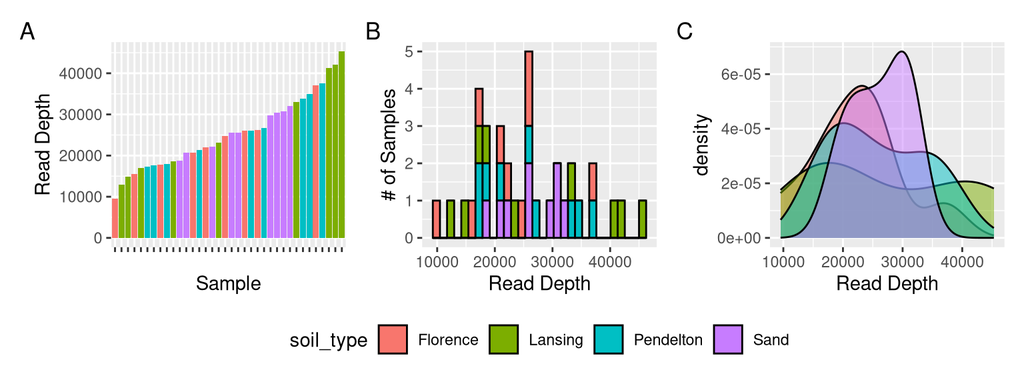

```r
# plot it as a bar plot
numSeq_bar_plot <-
  seqSums_df %>%
  ggplot(aes(x=reorder(sample_names, TotalSeqs), y = TotalSeqs,
             fill = soil_type)) +
  geom_bar(stat = "identity") +
  theme(axis.text.x = element_blank()) +
  labs(y = "Read Depth", x = "Sample") +
  theme(legend.position = "none")

# histogram
numSeq_hist_plot <-
  seqSums_df %>%
  ggplot(aes(x= TotalSeqs, fill = soil_type)) +
  geom_histogram(color = "black") +
  labs(y = "# of Samples", x = "Read Depth") +
  theme(legend.position = "bottom")

# Density plot
numSeq_density_plot <-
  seqSums_df %>%
  ggplot(aes(TotalSeqs, fill = soil_type)) +
  geom_density(alpha = 0.5) +
  labs(x = "Read Depth") +
  theme(legend.position = "none")

# Put it all together
numSeq_bar_plot + numSeq_hist_plot + numSeq_density_plot +
  plot_annotation(tag_levels = "A")
```

INTERPRETATION #5: I think the sequencing depth is ok. Most samples have over 10k reads. No samples should be removed at this point.

## Remove samples with few reads

If you find any samples that should obviously be removed at this step, you can follow the code below for your samples. However, if your samples have some but not many reads—like 1000 counts-it is worthwhile to keep those samples in your dataset and remove them later, especially if they are very important!

You can watch this video by [Dr. Pat Schloss](https://riffomonas.org/code_club/2022-04-07-sampling-depth), which talks about how to find the best sampling depth for rarefaction to give you some idea.

```r
# What's the min seq depth?
min(sample_sums(noChlorosMitosNegPosControls_physeq))
```

```
## [1] 9539
```

```r
raw_preprocessed_physeq <-
  noChlorosMitosNegPosControls_physeq

# Final check of the sequencing depth for now
# Here, we could remove more samples if we needed to
seqSums_df %>%
  dplyr::select(sample_names, TotalSeqs) %>%
  arrange(TotalSeqs) %>%
  head(n = 10)
```

```
##    sample_names TotalSeqs
## 1   SRR12183532      9539
## 2   SRR12183348     12870
## 3   SRR12183337     14939
## 4   SRR12183423     15587
## 5   SRR12183505     16961
## 6   SRR12183204     17350
## 7   SRR12183309     17586
## 8   SRR12183332     17747
## 9   SRR12183215     18007
## 10  SRR12183187     18647
```

# 9. Save Output

## Raw Preprocessed Phyloseq Object

Finally, let’s save our phyloseq object, which we will use for the next step!

```r
save(raw_preprocessed_physeq, file = "data/03_PreProcessing/raw_preprocessed_physeq.RData")
```

# Final info for Reproducibility